# seaborn tips

## seaborn : matplotlib 기반의 python 데이터 시각화 라이브러리 https://seaborn.pydata.org/

## 코드를 아래 셀에 쓰고 실행합니다. 실행한 결과를 보고 해석한 내용을 꼭 아래 셀에 써보세요!!

## 설명도 꼼꼼하게 읽어보세요!!!

```python
import pandas as pd
import matplotlib.pyplot as plt
```

```python
import seaborn as sns
```

### 1. 데이터

```python
df=sns.load_dataset('tips')     #내장 데이터 셋 사용
df.head()
```

|  | total_bill | tip | sex | smoker | day | time | size |
| --- | --- | --- | --- | --- | --- | --- | --- |
| 0 | 16.99 | 1.01 | Female | No | Sun | Dinner | 2 |
| 1 | 10.34 | 1.66 | Male | No | Sun | Dinner | 3 |
| 2 | 21.01 | 3.50 | Male | No | Sun | Dinner | 3 |
| 3 | 23.68 | 3.31 | Male | No | Sun | Dinner | 2 |
| 4 | 24.59 | 3.61 | Female | No | Sun | Dinner | 4 |

```python
df = sns.load_dataset('tips')
df
```

|  | total_bill | tip | sex | smoker | day | time | size |
| --- | --- | --- | --- | --- | --- | --- | --- |
| 0 | 16.99 | 1.01 | Female | No | Sun | Dinner | 2 |
| 1 | 10.34 | 1.66 | Male | No | Sun | Dinner | 3 |
| 2 | 21.01 | 3.50 | Male | No | Sun | Dinner | 3 |
| 3 | 23.68 | 3.31 | Male | No | Sun | Dinner | 2 |
| 4 | 24.59 | 3.61 | Female | No | Sun | Dinner | 4 |
| ... | ... | ... | ... | ... | ... | ... | ... |
| 239 | 29.03 | 5.92 | Male | No | Sat | Dinner | 3 |
| 240 | 27.18 | 2.00 | Female | Yes | Sat | Dinner | 2 |
| 241 | 22.67 | 2.00 | Male | Yes | Sat | Dinner | 2 |
| 242 | 17.82 | 1.75 | Male | No | Sat | Dinner | 2 |
| 243 | 18.78 | 3.00 | Female | No | Thur | Dinner | 2 |

244 rows × 7 columns

```python
df.info()
```

```
<class 'pandas.DataFrame'>
RangeIndex: 244 entries, 0 to 243
Data columns (total 7 columns):
 #   Column      Non-Null Count  Dtype
---  ------      --------------  -----
 0   total_bill  244 non-null    float64
 1   tip         244 non-null    float64
 2   sex         244 non-null    category
 3   smoker      244 non-null    category
 4   day         244 non-null    category
 5   time        244 non-null    category
 6   size        244 non-null    int64
dtypes: category(4), float64(2), int64(1)
memory usage: 7.4 KB
```

```python
df.describe()
```

|  | total_bill | tip | size |
| --- | --- | --- | --- |
| count | 244.000000 | 244.000000 | 244.000000 |
| mean | 19.785943 | 2.998279 | 2.569672 |
| std | 8.902412 | 1.383638 | 0.951100 |
| min | 3.070000 | 1.000000 | 1.000000 |
| 25% | 13.347500 | 2.000000 | 2.000000 |
| 50% | 17.795000 | 2.900000 | 2.000000 |
| 75% | 24.127500 | 3.562500 | 3.000000 |
| max | 50.810000 | 10.000000 | 6.000000 |

```python
# 색상
# sns.set_palette('pastel')
```

### 2-1. countplot : 성별에 따른 데이터 갯수

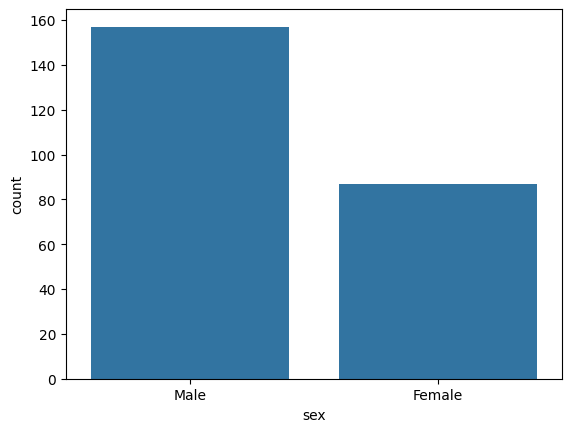

```python
sns.countplot(data=df, x='sex')
```

### 2-2. countplot : 요일별 데이터 수

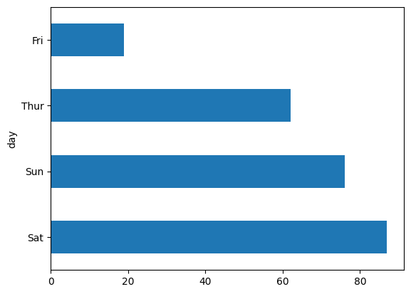

```python
df['day'].value_counts().plot(kind='barh')
```

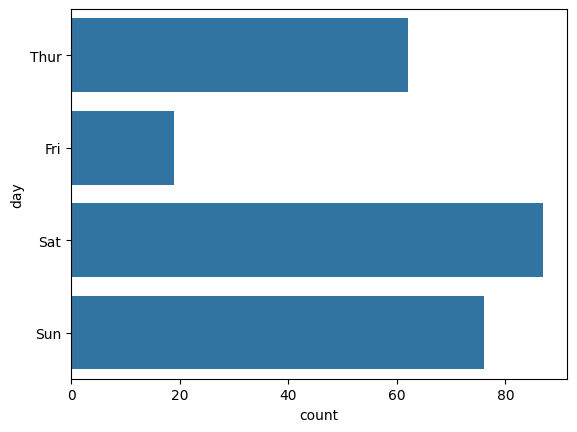

```python
sns.countplot(data=df, y='day')
```

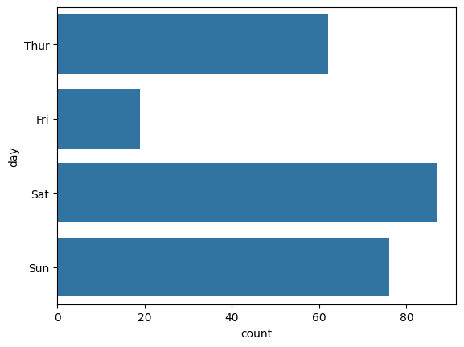

```python
sns.countplot(data=df, y='day')
```

### 3-1. barplot : 요일에 따른 평균 팁

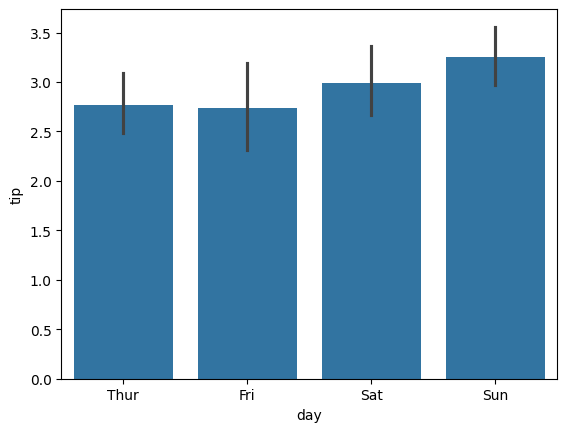

```python
sns.barplot(data=df, x='day',y='tip')
```

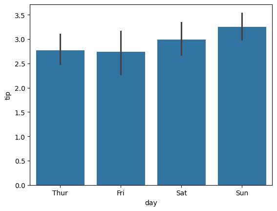

```python
sns.barplot(data=df, x='day', y= 'tip'   )
```

### 3-2. barplot : 성별에 따른 평균 팁

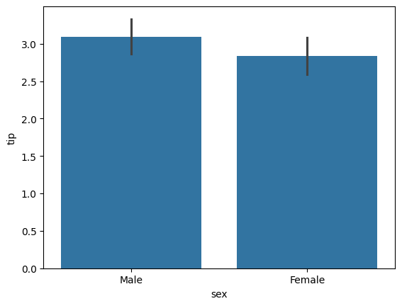

```python
sns.barplot(data=df, x='sex', y='tip')
```

### 3-2. barplot : 각 요일마다 성별로 또 나눠서 평균 팁 구하기

#### hue는 같은 x축 그룹 안에서 추가적으로 또 나누어 색깔로 표현하는 기능

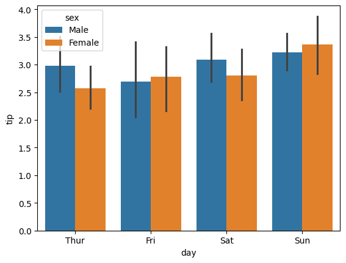

```python
sns.barplot(data=df, x='day',y='tip', hue='sex')
```

### 4. boxplot: 요일별 평균 팁 분포

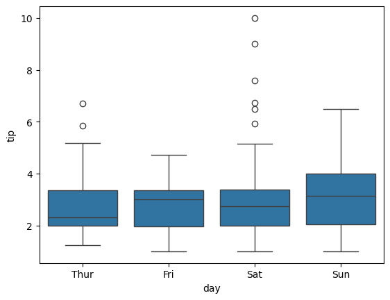

```python
sns.boxplot(data=df, x='day',y='tip'  )
```

해석 예 (여러분이 쓸때는 글로 이어지게 작성하세요)

- 최고 팁: 토요일(Sat) — 최대 10달러 이상 (이상치일 수 있음)
- 최저 팁: 모든 요일에서 약 1달러
- 중앙값이 가장 큰 요일: 일요일(Sun)
- 이상치가 가장 많은 요일: 토요일(Sat)
- 분산이 가장 작은 요일: 금요일(Fri)

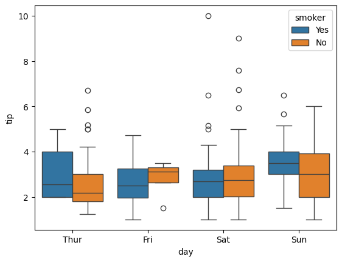

```python
sns.boxplot(data=df, x='day',y='tip',hue='smoker')
```

### 5. histplot: 팁 분포 보기

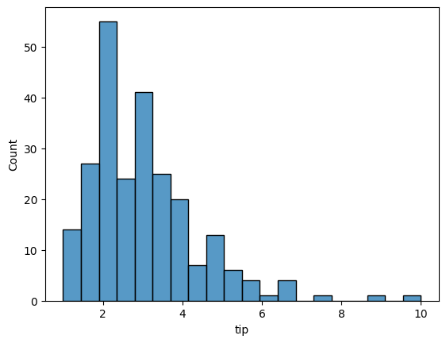

```python
sns.histplot(data=df, x='tip', bins=20)
```

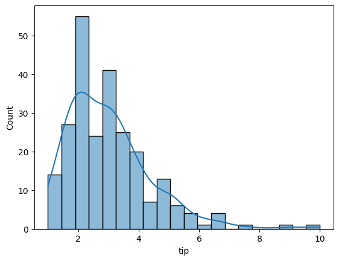

```python
sns.histplot(data=df, x='tip', bins=20, kde=True ) # kde=True : 데이터의 분포를 부드러운 곡선 형태로 추정해서 그려줌
```

그래프 해석

1. 비대칭적 분포 (오른쪽으로 꼬리)
- 대부분의 팁은 2~4달러 사이에 몰려 있음
- 10달러 정도의 팁은 거의 없음
- 오른쪽으로 긴 꼬리(long right tail) 를 가진 우측 비대칭 분포 (right-skewed distribution) (즉 항상 정규분포가 아님)
2. 최빈값 (가장 많은 값)
- 약 2달러 전후의 구간에 가장 많은 사람들이 팁을 주었음
- 2달러팁을 준 경우가 50건 이상으로 가장 많음
3. 이상치 존재 가능
- 6달러 이상 팁은 아주 드물게 발생
- 이런 값은 이상치(outlier) 일 수도 있고, 아닐 수도 있는데 모델링이나 평균 계산 시 주의가 필요
4. 중앙값 vs 평균
- 평균은 오른쪽 꼬리에 의해 끌려 올라갈 수 있음
- 따라서 중앙값 < 평균일 가능성이 높음
- 평균 대신 중앙값이 데이터를 대표하는 값이 되는 사례

해석 예: 대부분 손님은 2~4달러 사이의 팁을 주며, 데이터는 오른쪽으로 비대칭적이고 이상치도 존재함!

아래에 여러분의 해석을 적어보세요!!

### 6. scatterplot: 결제금액 vs 팁

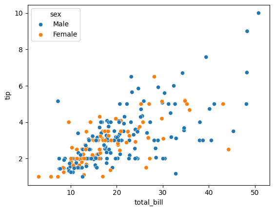

```python
sns.scatterplot(data=df, x='total_bill', y='tip', hue='sex')
```

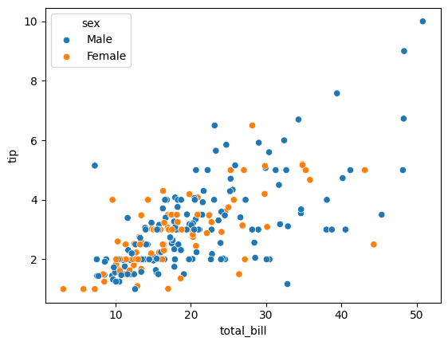

```python
sns.scatterplot(data=df, x='total_bill', y='tip',hue='sex'   )
```

그래프 해석

- 결제 금액이 클수록 팁도 증가하는 경향, 즉 더 많이 결제할수록 팁도 많이 주는 경향이 있음
- 전체적으로 우상향하는 패턴이므로 양의 상관관계가 있음
- 성별 차이 :
  - 남성과 여성 모두 유사한 패턴을 보임
  - 고액 팁(6~10달러)은 남성에게서 많이 관측됨
  - 여성은 중간 정도의 결제금액 (~30달러)까지 팁 분포가 더 좁은 편
- 고액 결제와 고액 팁은 드문 조합이라 이상치 또는 VIP일 수 있음

아래에 여러분의 해석을 적어보세요!!

### 7. pairplot: 수치형 전체 관계 보기

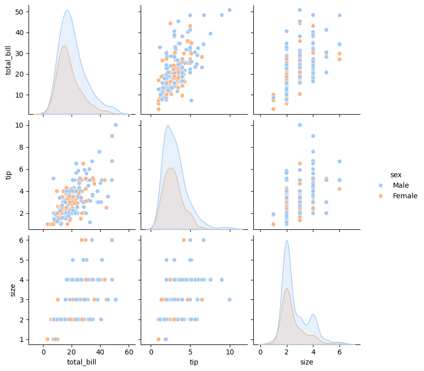

```python
sns.pairplot(df, hue='sex', palette='pastel')
```

#### total_bill, tip, size 세 변수 간의 관계를 성별기준으로 시각화

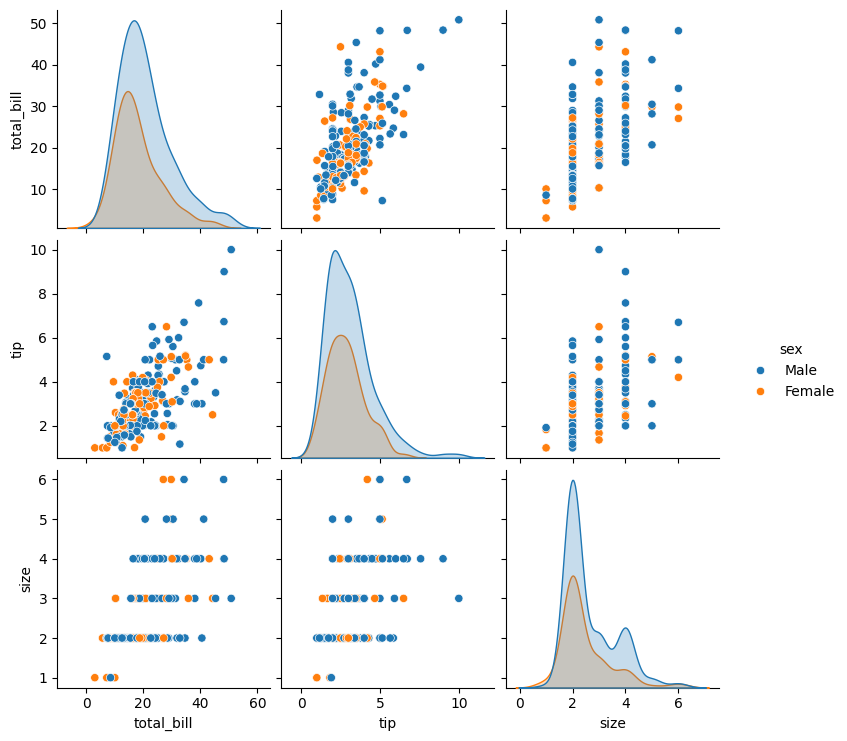

```python
sns.pairplot(df[['total_bill', 'tip', 'size', 'sex']], hue='sex')
```

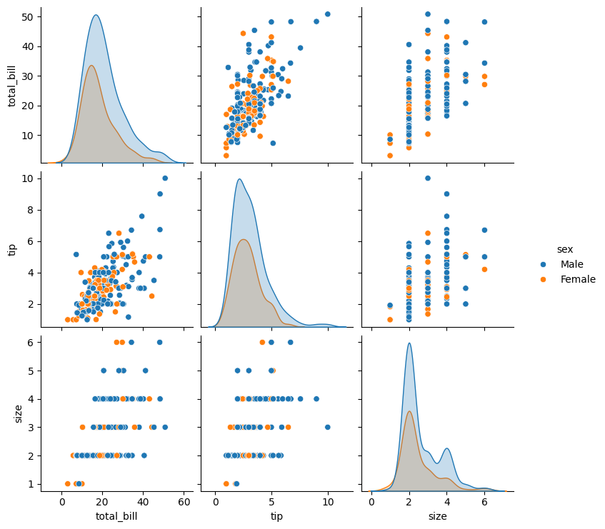

```python
sns.pairplot(df[['total_bill', 'tip', 'size', 'sex']]  ,hue=  'sex'    )
```

### 8. violinplot: 요일에 따른 총 결제금액

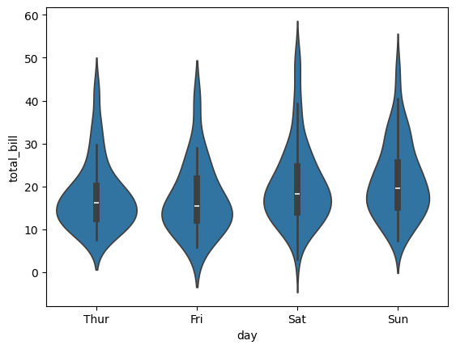

```python
sns.violinplot(data=df, x='day',y='total_bill')
```

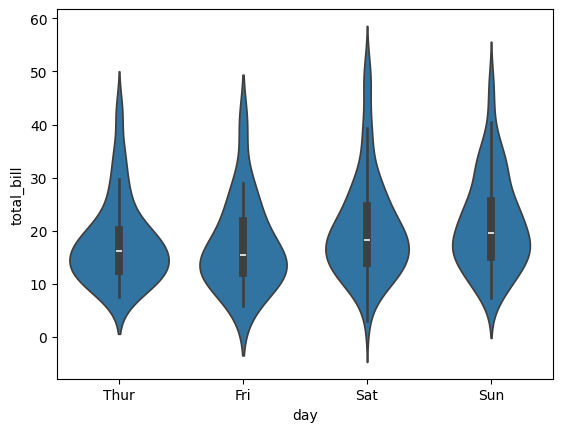

```python
sns.violinplot(data=df, x='day' ,   y='total_bill'   )
```

violinplot 구성요소

- 중심 흰 점 : 중앙값 (Median)
- 굵은 검정 막대 : IQR (Interquartile Range) = Q1~Q3
- 전체 실루엣(모양) : 분포의 밀도 (KDE) — 부풀수록 데이터가 많다는 뜻

### 요일별 결제금액 분포 비교

[output not shown]

[output not shown]

해석 예

토요일(Sat): 가장 넓고 고액 결제도 많음 즉 가장 비싼 손님 많음

목요일(Thur): 가장 집중된 분포로 예측 안정성 좋음

### 9. 상관계수 구하기와 heatmap

### 상관계수(correlation coefficient)

| 값 범위 | 의미 |
| --- | --- |
| +1에 가까울수록 | 강한 양의 상관관계 (같이 증가) |
| 0에 가까울수록 | 거의 무관 |
| -1에 가까울수록 | 강한 음의 상관관계 (한쪽이 증가할 때 다른 쪽은 감소) |

```python
df[['total_bill', 'tip', 'size']].corr()
```

|  | total_bill | tip | size |
| --- | --- | --- | --- |
| total_bill | 1.000000 | 0.675734 | 0.598315 |
| tip | 0.675734 | 1.000000 | 0.489299 |
| size | 0.598315 | 0.489299 | 1.000000 |

```python
df[['total_bill', 'tip', 'size']].corr()
```

|  | total_bill | tip | size |
| --- | --- | --- | --- |
| total_bill | 1.000000 | 0.675734 | 0.598315 |
| tip | 0.675734 | 1.000000 | 0.489299 |
| size | 0.598315 | 0.489299 | 1.000000 |

### 수치값으로 상관계수를 나타낼 수도 있으나 데이터의 크기가 커지게 되면 이 상관계수를 한 눈에 파악하기에 불편해짐 따라서 이를 히트맵으로 나타내어 파악하기 쉽게 만듦

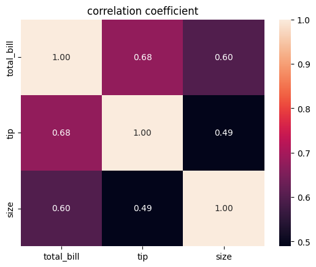

```python
corr=df[['total_bill', 'tip', 'size']].corr()
sns.heatmap(corr, annot=True, fmt='.2f')
plt.title('correlation coefficient')
# plt.savefig('tip_heatmap.png')    # 주의: 반드시 파일로 저장하는 plt.savefig()를 plt.show() 전에 해야 함
plt.show()
```

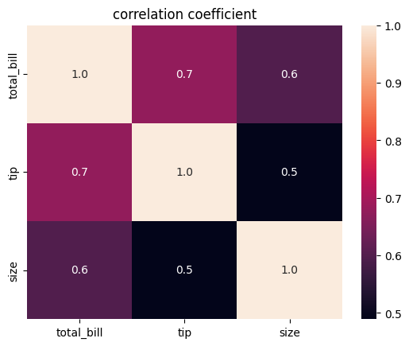

```python
corr = df[['total_bill', 'tip', 'size']].corr()
sns.heatmap(corr, annot=True, fmt='.1f'   )
plt.title('correlation coefficient')
plt.show()
```

여러분의 해석을 아래에 적어보세요

```python
df = pd.read_csv('netflix_titles.csv')
df
```

|  | show_id | type | title | director | cast | country | date_added | release_year | rating | duration | listed_in | description |
| --- | --- | --- | --- | --- | --- | --- | --- | --- | --- | --- | --- | --- |
| 0 | s1 | Movie | Dick Johnson Is Dead | Kirsten Johnson | NaN | United States | September 25, 2021 | 2020 | PG-13 | 90 min | Documentaries | As her father nears the end of his life, filmm... |
| 1 | s2 | TV Show | Blood & Water | NaN | Ama Qamata, Khosi Ngema, Gail Mabalane, Thaban... | South Africa | September 24, 2021 | 2021 | TV-MA | 2 Seasons | International TV Shows, TV Dramas, TV Mysteries | After crossing paths at a party, a Cape Town t... |
| 2 | s3 | TV Show | Ganglands | Julien Leclercq | Sami Bouajila, Tracy Gotoas, Samuel Jouy, Nabi... | NaN | September 24, 2021 | 2021 | TV-MA | 1 Season | Crime TV Shows, International TV Shows, TV Act... | To protect his family from a powerful drug lor... |
| 3 | s4 | TV Show | Jailbirds New Orleans | NaN | NaN | NaN | September 24, 2021 | 2021 | TV-MA | 1 Season | Docuseries, Reality TV | Feuds, flirtations and toilet talk go down amo... |
| 4 | s5 | TV Show | Kota Factory | NaN | Mayur More, Jitendra Kumar, Ranjan Raj, Alam K... | India | September 24, 2021 | 2021 | TV-MA | 2 Seasons | International TV Shows, Romantic TV Shows, TV ... | In a city of coaching centers known to train I... |
| ... | ... | ... | ... | ... | ... | ... | ... | ... | ... | ... | ... | ... |
| 8802 | s8803 | Movie | Zodiac | David Fincher | Mark Ruffalo, Jake Gyllenhaal, Robert Downey J... | United States | November 20, 2019 | 2007 | R | 158 min | Cult Movies, Dramas, Thrillers | A political cartoonist, a crime reporter and a... |
| 8803 | s8804 | TV Show | Zombie Dumb | NaN | NaN | NaN | July 1, 2019 | 2018 | TV-Y7 | 2 Seasons | Kids' TV, Korean TV Shows, TV Comedies | While living alone in a spooky town, a young g... |
| 8804 | s8805 | Movie | Zombieland | Ruben Fleischer | Jesse Eisenberg, Woody Harrelson, Emma Stone, ... | United States | November 1, 2019 | 2009 | R | 88 min | Comedies, Horror Movies | Looking to survive in a world taken over by zo... |
| 8805 | s8806 | Movie | Zoom | Peter Hewitt | Tim Allen, Courteney Cox, Chevy Chase, Kate Ma... | United States | January 11, 2020 | 2006 | PG | 88 min | Children & Family Movies, Comedies | Dragged from civilian life, a former superhero... |
| 8806 | s8807 | Movie | Zubaan | Mozez Singh | Vicky Kaushal, Sarah-Jane Dias, Raaghav Chanan... | India | March 2, 2019 | 2015 | TV-14 | 111 min | Dramas, International Movies, Music & Musicals | A scrappy but poor boy worms his way into a ty... |

8807 rows × 12 columns

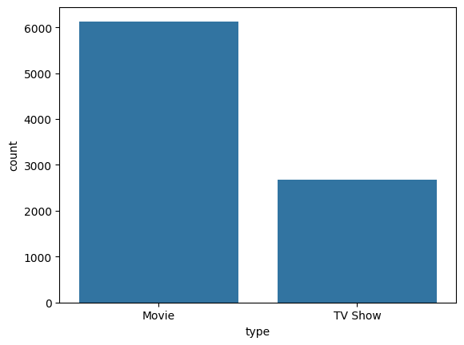

```python
sns.countplot(data=df,  x='type')
plt.show()
```

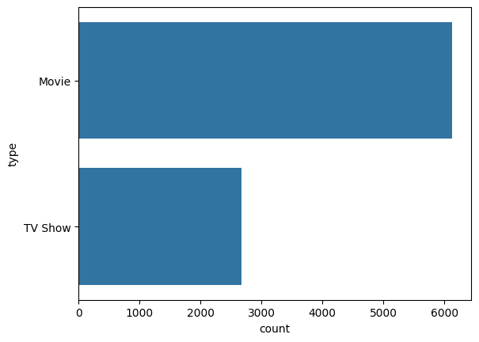

```python
sns.countplot(data=df, y='type')
```

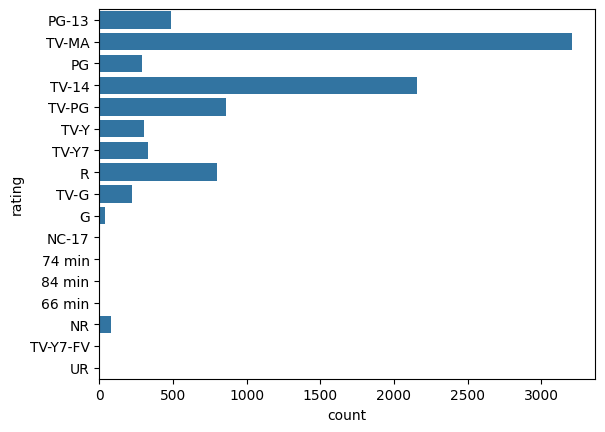

```python
sns.countplot(data=df, y='rating')
```